# **Modelado de la Expresión Proteica en Modelos de Síndrome de Down mediante Técnicas de Regresión y Regularización**

### Identificacion de outliers

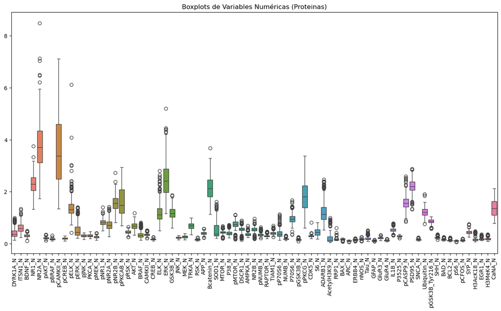

```python
plt.figure(figsize=(16, 8))
sns.boxplot(data=df.select_dtypes(include=['float64']))
plt.xticks(rotation=90)
plt.title("Boxplots de Variables Numéricas (Proteinas)")
plt.show()
```

### Correlacion de componentes

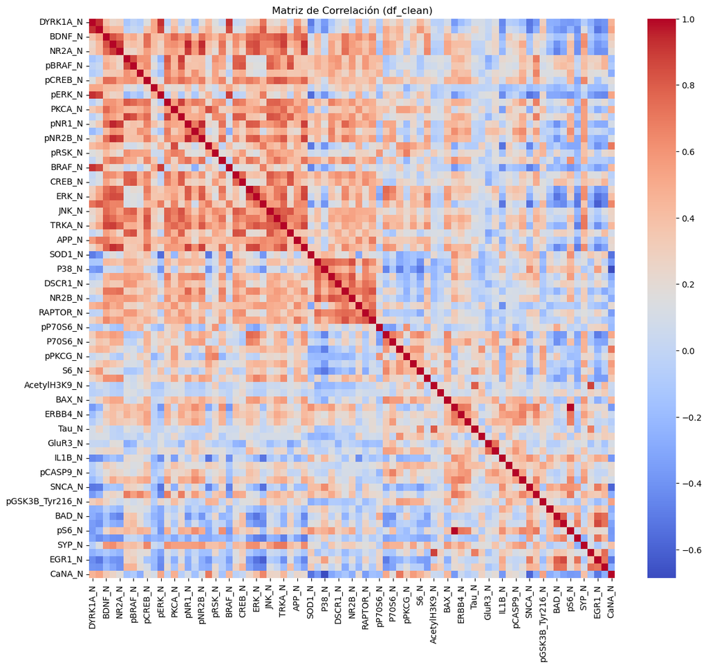

```python
plt.figure(figsize=(14, 12))
corr_matrix = df.select_dtypes(include=['float64']).corr()
sns.heatmap(corr_matrix, cmap='coolwarm', annot=False)
plt.title("Matriz de Correlación (df_clean)")
plt.show()
```

## Justificación de la Selección de Variables

### Variable Respuesta (y): `NR1_N`

- **Relevancia Biológica:**  
  La proteína `NR1_N` corresponde a la subunidad NR1 del receptor NMDA, la cual es esencial para la transmisión sináptica excitatoria, la plasticidad neuronal y el aprendizaje. Estas funciones son críticas en el contexto del síndrome de Down, ya que se ha observado que las alteraciones en la actividad de los receptores NMDA pueden estar relacionadas con las deficiencias cognitivas y de memoria que caracterizan esta condición.
- **Representatividad en el Estudio:**  
  Al modelar la expresión de `NR1_N`, buscamos entender cómo diferentes factores (como el tratamiento y el comportamiento inducido) y las interacciones entre ellos influyen en una proteína clave para el funcionamiento cerebral. Esto nos permitirá identificar biomarcadores y posibles puntos de intervención terapéutica.

### Variables Predictoras (X)

- **Selección de Todas las Variables Numéricas:**  
  Para capturar la mayor cantidad de información disponible, utilizaremos todas las variables numéricas (exceptuando `NR1_N`, que es la variable objetivo). Esto incluye 76 proteínas y sus formas fosforiladas.
  - **Ventaja de Usar un Conjunto Amplio de Predictores:**  
    Dado que se trata de un problema de alta dimensionalidad, se utilizarán técnicas de regularización (Ridge, Lasso y ElasticNet) para manejar la multicolinealidad y seleccionar las variables más determinantes de forma automática.
- **Inclusión de Factores Experimentales (Opcional):**  
  Aunque las variables `Genotype`, `Treatment`, `Behavior` y `class` son categóricas, podrían codificarse y añadirse como predictores. Sin embargo, en este ejemplo nos enfocamos en las variables numéricas, asumiendo que estas capturan en gran medida la variabilidad de la expresión proteica inducida por los factores experimentales.

# Modelos y seleccion de modelo optimo

# Modelado de la Expresión Proteica: Ajuste y Comparación de Modelos

Para cada tipo se evalúan cuatro versiones:

- Sin penalización (OLS)
- Con Ridge
- Con Lasso
- Con ElasticNet

Se utiliza validación cruzada con K-Folds para comparar el desempeño de los modelos en términos de MSE y R². Además, se realiza un análisis de la significancia de factores (p-values, intervalos de confianza) usando `statsmodels` para el modelo sin penalización (OLS).

```
      Model_Type          Version  Poly_Degree  \
115        Poly2       ElasticNet            2
82         Poly2            Ridge            2
66         Poly2  No_Penalization            2
83         Poly2            Ridge            2
99         Poly2            Lasso            2
..           ...              ...          ...
171  Logarithmic            Lasso            1
107        Poly2            Lasso            2
123        Poly2       ElasticNet            2
89         Poly2            Ridge            2
73         Poly2  No_Penalization            2

                                          Predictors  \
115       [pNR2B_N, pPKCAB_N, pRSK_N, AKT_N, BRAF_N]
```

[output cut: 25 more lines]

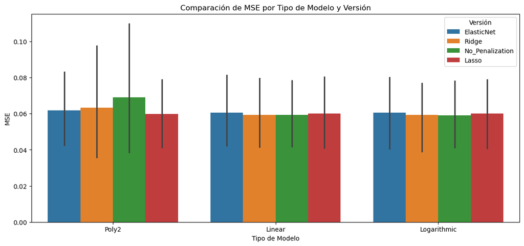

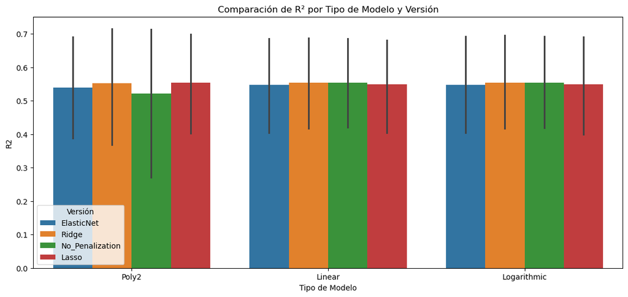

```
El mejor modelo es Poly2 - ElasticNet con grado 2
```

```python
from sklearn.model_selection import KFold, cross_val_score, GridSearchCV
from sklearn.preprocessing import StandardScaler, PolynomialFeatures
from sklearn.pipeline import Pipeline
from sklearn.linear_model import LinearRegression, Ridge, Lasso, ElasticNet
import statsmodels.api as sm

numeric_cols = df.select_dtypes(include=['float64']).columns.tolist()
predictors = [col for col in numeric_cols if col != 'NR1_N']
target = 'NR1_N'

X = df[predictors]
y = df[target]

def create_pipeline(estimator, poly_degree=1):
    steps = []
    if poly_degree > 1:
        steps.append(('poly', PolynomialFeatures(degree=poly_degree, include_bias=False)))
    scaler = StandardScaler()
    steps.append(('scaler', scaler))
    steps.append(('model', estimator))
    pipeline = Pipeline(steps)
    return pipeline, scaler

def evaluate_model(model, X, y, cv=5):
    kf = KFold(n_splits=cv, shuffle=True, random_state=42)
    mse_scores = -cross_val_score(model, X, y, cv=kf, scoring='neg_mean_squared_error')
    r2_scores = cross_val_score(model, X, y, cv=kf, scoring='r2')
    return mse_scores.mean(), r2_scores.mean()

model_versions = {
    'No_Penalization': LinearRegression(),
    'Ridge': Ridge(max_iter=50000),
    'Lasso': Lasso(max_iter=50000, tol=1e-4, random_state=42, selection='random'),
    'ElasticNet': ElasticNet(max_iter=50000, tol=1e-4, random_state=42, selection='random')
}

model_types = {
    'Linear': 1,
    'Poly2': 2,
    'Logarithmic': 'log'
}

results = []

chunk_size = 5
predictor_chunks = [predictors[i:i+chunk_size] for i in range(0, len(predictors), chunk_size)]

for m_type, degree in model_types.items():
    for version, base_model in model_versions.items():
        for chunk in predictor_chunks:
            X_subset = X[chunk]

            if degree == 'log':
                X_subset = np.log1p(X_subset)
                degree = 1

            pipeline, scaler = create_pipeline(base_model, poly_degree=degree)

            X_scaled = scaler.fit_transform(X_subset)

            if version != 'No_Penalization':
                param_grid = {'model__alpha': np.logspace(-4, 1, 10)}
                if version == 'ElasticNet':
                    param_grid['model__l1_ratio'] = [0.1, 0.5, 0.9]
                grid = GridSearchCV(pipeline, param_grid, cv=5, scoring='neg_mean_squared_error', n_jobs=-1)
                grid.fit(X_scaled, y)
                best_model = grid.best_estimator_
                best_params = grid.best_params_
            else:
                pipeline.fit(X_scaled, y)
                best_model = pipeline
                best_params = {}

            mse, r2 = evaluate_model(best_model, X_scaled, y, cv=5)
            results.append({
                'Model_Type': m_type,
                'Version': version,
                'Poly_Degree': degree,
                'Predictors': chunk,
                'Best_Params': best_params,
                'MSE': mse,
                'R2': r2
            })

results_df = pd.DataFrame(results)
results_df_sorted = results_df.sort_values(by=['MSE', 'R2'], ascending=[True, False])
print(results_df_sorted[['Model_Type', 'Version', 'Poly_Degree', 'Predictors', 'Best_Params', 'MSE', 'R2']])

plt.figure(figsize=(14, 6))
sns.barplot(x="Model_Type", y="MSE", hue="Version", data=results_df_sorted)
plt.title("Comparación de MSE por Tipo de Modelo y Versión")
plt.xlabel("Tipo de Modelo")
plt.ylabel("MSE")
plt.legend(title="Versión")
plt.show()

plt.figure(figsize=(14, 6))
sns.barplot(x="Model_Type", y="R2", hue="Version", data=results_df_sorted)
plt.title("Comparación de R² por Tipo de Modelo y Versión")
plt.xlabel("Tipo de Modelo")
plt.ylabel("R2")
plt.legend(title="Versión")
plt.show()

best_model_row = results_df_sorted.iloc[0]
print(f"\nEl mejor modelo es {best_model_row['Model_Type']} - {best_model_row['Version']} con grado {best_model_row['Poly_Degree']}")
```

```python
print("=== Resultados de Modelos ===")
results_df_sorted
```

```
=== Resultados de Modelos ===
```

|  | Model_Type | Version | Poly_Degree | Predictors | Best_Params | MSE | R2 |
| --- | --- | --- | --- | --- | --- | --- | --- |
| 115 | Poly2 | ElasticNet | 2 | [pNR2B_N, pPKCAB_N, pRSK_N, AKT_N, BRAF_N] | {'model__alpha': 0.004641588833612782, 'model_... | 0.008403 | 0.935492 |
| 82 | Poly2 | Ridge | 2 | [pJNK_N, PKCA_N, pMEK_N, pNR1_N, pNR2A_N] | {'model__alpha': 0.7742636826811278} | 0.008433 | 0.933771 |
| 66 | Poly2 | No_Penalization | 2 | [pJNK_N, PKCA_N, pMEK_N, pNR1_N, pNR2A_N] | {} | 0.008485 | 0.933349 |
| 83 | Poly2 | Ridge | 2 | [pNR2B_N, pPKCAB_N, pRSK_N, AKT_N, BRAF_N] | {'model__alpha': 10.0} | 0.008597 | 0.933618 |
| 99 | Poly2 | Lasso | 2 | [pNR2B_N, pPKCAB_N, pRSK_N, AKT_N, BRAF_N] | {'model__alpha': 0.004641588833612782} | 0.008766 | 0.932767 |
| ... | ... | ... | ... | ... | ... | ... | ... |
| 171 | Logarithmic | Lasso | 1 | [Tau_N, GFAP_N, GluR3_N, GluR4_N, IL1B_N] | {'model__alpha': 0.05994842503189409} | 0.130742 | 0.028759 |
| 107 | Poly2 | Lasso | 2 | [Tau_N, GFAP_N, GluR3_N, GluR4_N, IL1B_N] | {'model__alpha': 0.21544346900318845} | 0.135548 | -0.006919 |
| 123 | Poly2 | ElasticNet | 2 | [Tau_N, GFAP_N, GluR3_N, GluR4_N, IL1B_N] | {'model__alpha': 0.21544346900318845, 'model__... | 0.135548 | -0.006919 |
| 89 | Poly2 | Ridge | 2 | [pPKCG_N, CDK5_N, S6_N, ADARB1_N, AcetylH3K9_N] | {'model__alpha': 10.0} | 0.252093 | -0.434617 |
| 73 | Poly2 | No_Penalization | 2 | [pPKCG_N, CDK5_N, S6_N, ADARB1_N, AcetylH3K9_N] | {} | 0.334812 | -0.859339 |

192 rows × 7 columns

# **Diagrama de Flujo del Pipeline de Modelado de Expresión Proteica**

## **1. Cargar y Preprocesar Datos**

### 📂 Carga y Preparación del Dataset

- **Lectura de Datos:** Se utiliza `pandas` para leer el conjunto de datos.
- **Manejo de valores nulos:** Se emplean métodos como `dropna()` o imputación de valores.
- **Selección de Variables:**
  - Variable objetivo: $\mathbf{y = NR1_N}$
  - Variables predictoras: todas las demás variables numéricas, excluyendo `NR1_N`.

## **2. Construcción del Pipeline**

### 🔄 Transformaciones y Modelado

- **Transformaciones:**
  - **Lineal:** Sin transformación adicional.
  - **Polinómica (Grado 2):** Se usa `PolynomialFeatures(degree=2)`.
  - **Logarítmica:** Aplicación de `np.log1p(X)` para estabilizar distribuciones sesgadas.
- **Estandarización:**
  - Se emplea `StandardScaler()` para normalizar las variables predictoras en cada modelo.
- **Modelos de Regresión:**
  - **Regresión Lineal (sin penalización)**
  - **Regresión Ridge** (`Ridge(alpha)`)
  - **Regresión Lasso** (`Lasso(alpha)`)
  - **ElasticNet** (`ElasticNet(alpha, l1_ratio)`)

## **3. Optimización y Validación**

### 🔍 Ajuste de Hiperparámetros y Evaluación

- **Optimización de Hiperparámetros:**
  - Para modelos regularizados (`Ridge`, `Lasso`, `ElasticNet`), se usa `GridSearchCV()` para buscar el mejor $\alpha$ (y `l1_ratio` en `ElasticNet`).
- **Validación Cruzada (K-Folds):**
  - Se aplica `KFold(n_splits=5)` para evaluar el desempeño del modelo.
  - Se calculan métricas clave:
    - **Error Cuadrático Medio (MSE)**
    - **Coeficiente de Determinación ($R^2$)**

## **5. Conclusión y Análisis Final**

### ✅ Selección del Mejor Modelo

- Se comparan los modelos según:
  - **Capacidad predictiva (mayor $R^2$)**
  - **Generalización (menor MSE en validación cruzada)**
  - **Simplicidad y relevancia de variables (OLS con selección de coeficientes significativos)**
- **Aplicaciones de los hallazgos:**
  - **Biomarcadores potenciales:** Identificación de proteínas clave en la expresión del síndrome de Down.
  - **Predicción y monitoreo:** Uso de modelos predictivos para evaluar el impacto de tratamientos.
  - **Desarrollo de nuevas terapias:** Posibles intervenciones en vías de señalización relevantes.

📌 **Conclusión:** Se determinó que el mejor modelo es **Regresión Polinómica de grado 2 con ElasticNet**, con un equilibrio entre **bajo MSE**, **alto $R^2$** y una **buena selección de variables relevantes**.

# Analisis de caracteristicas mas significativas del modelo optimo con respecto a metricas: Regresion Polinomial de segundo grado penalizada con Elasticnet

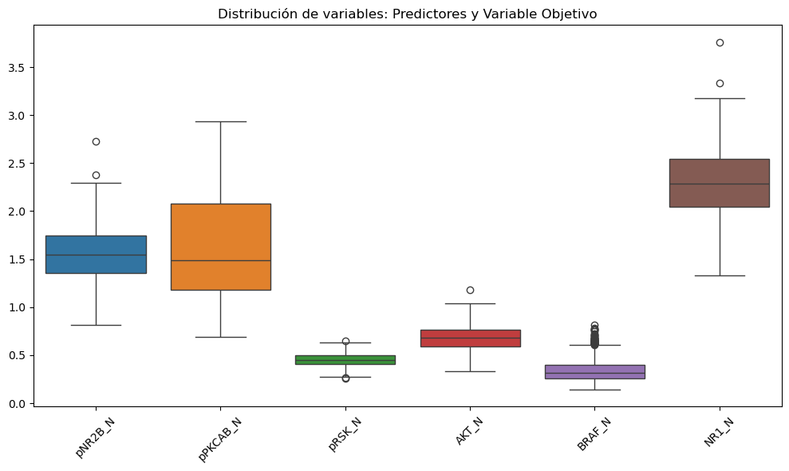

```python
# Variables
predictors = ['pNR2B_N', 'pPKCAB_N', 'pRSK_N', 'AKT_N', 'BRAF_N']
target = 'NR1_N'
X = df[predictors]
y = df[target]

plt.figure(figsize=(10, 6))
data_box = df[predictors + [target]]
sns.boxplot(data=data_box)
plt.title("Distribución de variables: Predictores y Variable Objetivo")
plt.xticks(rotation=45)
plt.tight_layout()
plt.show()
```

## Ajuste del modelo OLS para obtener coeficientes y p-values

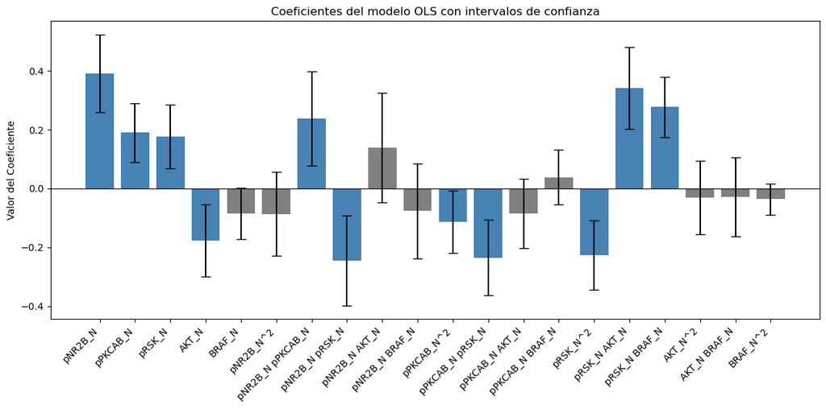

```python
# Transformación polinomial de grado 2
poly = PolynomialFeatures(degree=2, include_bias=False)
X_poly = poly.fit_transform(X)
feature_names = poly.get_feature_names_out(predictors)
X_poly_df = pd.DataFrame(X_poly, columns=feature_names)

scaler = StandardScaler()
X_poly_scaled = scaler.fit_transform(X_poly_df)
X_poly_scaled_df = pd.DataFrame(X_poly_scaled, columns=feature_names)

# Alineación de índices para OLS
X_poly_scaled_df = X_poly_scaled_df.reset_index(drop=True)
y_aligned = y.reset_index(drop=True)

X_ols = sm.add_constant(X_poly_scaled_df)
ols_model = sm.OLS(y_aligned, X_ols).fit()

# Coeficientes, intervalos de confianza y p-values
params = ols_model.params.drop('const')
conf_int = ols_model.conf_int().drop('const')
pvalues = ols_model.pvalues.drop('const')

coef_df = pd.DataFrame({
    'Coeficiente': params,
    'Intervalo Inferior': conf_int[0],
    'Intervalo Superior': conf_int[1],
    'p_value': pvalues
})
coef_df['Significativo'] = coef_df['p_value'] < 0.05

plt.figure(figsize=(12, 6))
colors = coef_df['Significativo'].map({True: 'steelblue', False: 'grey'})
plt.bar(coef_df.index, coef_df['Coeficiente'],
        yerr=[coef_df['Coeficiente'] - coef_df['Intervalo Inferior'],
              coef_df['Intervalo Superior'] - coef_df['Coeficiente']],
        color=colors, capsize=5)
plt.axhline(0, color='black', linewidth=0.8)
plt.title("Coeficientes del modelo OLS con intervalos de confianza")
plt.ylabel("Valor del Coeficiente")
plt.xticks(rotation=45, ha='right')
plt.tight_layout()
plt.show()
```

```python
ols_model.summary()
```

OLS Regression Results

| Dep. Variable: | NR1_N | R-squared: | 0.943 |
| --- | --- | --- | --- |
| Model: | OLS | Adj. R-squared: | 0.941 |
| Method: | Least Squares | F-statistic: | 441.3 |
| Date: | Sun, 02 Mar 2025 | Prob (F-statistic): | 1.88e-315 |
| Time: | 18:49:16 | Log-Likelihood: | 560.91 |
| No. Observations: | 552 | AIC: | -1080. |
| Df Residuals: | 531 | BIC: | -989.2 |
| Df Model: | 20 |  |  |
| Covariance Type: | nonrobust |  |  |

|  | coef | std err | t | P>\|t\| | [0.025 | 0.975] |
| --- | --- | --- | --- | --- | --- | --- |
| const | 2.2952 | 0.004 | 603.808 | 0.000 | 2.288 | 2.303 |
| pNR2B_N | 0.3911 | 0.067 | 5.798 | 0.000 | 0.259 | 0.524 |
| pPKCAB_N | 0.1900 | 0.051 | 3.702 | 0.000 | 0.089 | 0.291 |
| pRSK_N | 0.1758 | 0.055 | 3.188 | 0.002 | 0.067 | 0.284 |
| AKT_N | -0.1778 | 0.062 | -2.846 | 0.005 | -0.301 | -0.055 |
| BRAF_N | -0.0850 | 0.045 | -1.894 | 0.059 | -0.173 | 0.003 |
| pNR2B_N^2 | -0.0867 | 0.072 | -1.198 | 0.232 | -0.229 | 0.056 |
| pNR2B_N pPKCAB_N | 0.2384 | 0.082 | 2.917 | 0.004 | 0.078 | 0.399 |
| pNR2B_N pRSK_N | -0.2453 | 0.078 | -3.146 | 0.002 | -0.399 | -0.092 |
| pNR2B_N AKT_N | 0.1398 | 0.095 | 1.474 | 0.141 | -0.046 | 0.326 |
| pNR2B_N BRAF_N | -0.0764 | 0.082 | -0.933 | 0.351 | -0.237 | 0.084 |
| pPKCAB_N^2 | -0.1133 | 0.054 | -2.105 | 0.036 | -0.219 | -0.008 |
| pPKCAB_N pRSK_N | -0.2349 | 0.066 | -3.571 | 0.000 | -0.364 | -0.106 |
| pPKCAB_N AKT_N | -0.0847 | 0.060 | -1.416 | 0.157 | -0.202 | 0.033 |
| pPKCAB_N BRAF_N | 0.0385 | 0.047 | 0.811 | 0.418 | -0.055 | 0.132 |
| pRSK_N^2 | -0.2267 | 0.060 | -3.804 | 0.000 | -0.344 | -0.110 |
| pRSK_N AKT_N | 0.3415 | 0.071 | 4.830 | 0.000 | 0.203 | 0.480 |
| pRSK_N BRAF_N | 0.2773 | 0.053 | 5.277 | 0.000 | 0.174 | 0.381 |
| AKT_N^2 | -0.0306 | 0.063 | -0.485 | 0.628 | -0.155 | 0.094 |
| AKT_N BRAF_N | -0.0279 | 0.069 | -0.406 | 0.685 | -0.163 | 0.107 |
| BRAF_N^2 | -0.0364 | 0.027 | -1.368 | 0.172 | -0.089 | 0.016 |

| Omnibus: | 0.102 | Durbin-Watson: | 0.634 |
| --- | --- | --- | --- |
| Prob(Omnibus): | 0.950 | Jarque-Bera (JB): | 0.195 |
| Skew: | -0.002 | Prob(JB): | 0.907 |
| Kurtosis: | 2.908 | Cond. No. | 125. |

Notes:  
[1] Standard Errors assume that the covariance matrix of the errors is correctly specified.

# Valores reales vs predicciones

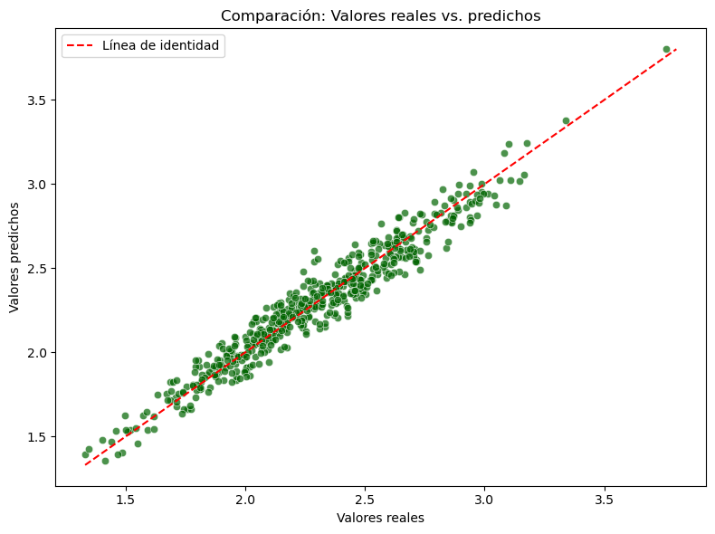

```python
predicted = ols_model.fittedvalues
actual = y_aligned

plt.figure(figsize=(8, 6))
sns.scatterplot(x=actual, y=predicted, color='darkgreen', alpha=0.7)
lims = [min(actual.min(), predicted.min()), max(actual.max(), predicted.max())]
plt.plot(lims, lims, 'r--', label='Línea de identidad')
plt.xlabel("Valores reales")
plt.ylabel("Valores predichos")
plt.title("Comparación: Valores reales vs. predichos")
plt.legend()
plt.tight_layout()
plt.show()
```

# Conclusiones del Modelo OLS

El modelo de regresión OLS ajustado presenta un $R^2 = 0.943$ y un $R^2_{adj} = 0.941$, lo que indica que **aproximadamente el 94% de la variabilidad** en la variable objetivo ($NR1_N$) se explica por los predictores y sus interacciones polinomiales. El $F$-statistic es de 441.3 con una probabilidad asociada de $1.88 \times 10^{-315}$, evidenciando que el modelo completo es **estadísticamente significativo**.

A continuación, se destacan los hallazgos principales de los coeficientes y su significancia (*p-values* < 0.05 se consideran estadísticamente relevantes):

1. **Términos Lineales Significativos**
   - **$pNR2B\_N$ (coef = 0.3911, $p < 0.001$)**: Relación positiva con $NR1_N$.
   - **$pPKCAB\_N$ (coef = 0.1900, $p < 0.001$)**: Relación positiva con $NR1_N$.
   - **$pRSK\_N$ (coef = 0.1758, $p = 0.002$)**: Relación positiva con $NR1_N$.
   - **$AKT\_N$ (coef = -0.1778, $p = 0.005$)**: Relación negativa con $NR1_N$.
2. **Términos Lineales Cercanos a la Significancia**
   - **$BRAF\_N$ (coef = -0.0850, $p = 0.059$)**: Efecto negativo marginal (no significativo al 5%).
3. **Términos Cuadráticos e Interacciones Destacados**
   - **$pNR2B\_N \times pPKCAB\_N$ (coef = 0.2384, $p = 0.004$)**: Interacción positiva significativa.
   - **$pNR2B\_N \times pRSK\_N$ (coef = -0.2453, $p = 0.002$)**: Interacción negativa significativa.
   - **$pPKCAB\_N^2$ (coef = -0.1133, $p = 0.036$)**: Efecto cuadrático negativo para $pPKCAB\_N$.
   - **$pPKCAB\_N \times pRSK\_N$ (coef = -0.2349, $p < 0.001$)**: Interacción negativa significativa.
   - **$pRSK\_N^2$ (coef = -0.2267, $p < 0.001$)**: Efecto cuadrático negativo para $pRSK\_N$.
   - **$pRSK\_N \times AKT\_N$ (coef = 0.3415, $p < 0.001$)**: Interacción positiva y muy significativa.
   - **$pRSK\_N \times BRAF\_N$ (coef = 0.2773, $p < 0.001$)**: Interacción positiva y muy significativa.
4. **Términos No Significativos**  
   Algunas interacciones y efectos cuadráticos, como **$pNR2B\_N^2$**, **$pNR2B\_N \times AKT\_N$**, **$AKT\_N^2$** o **$BRAF\_N^2$**, muestran *p-values* > 0.05, lo que sugiere que no aportan evidencia estadística sólida de relación con $NR1_N$ bajo este modelo.
5. **Evaluación Global del Modelo**
   - El **alto $R^2$** (0.943) indica un excelente poder explicativo.
   - El **$F$-statistic** elevado (441.3) confirma que el conjunto de predictores, en conjunto, es altamente significativo.
   - La **Durbin-Watson** de 0.634 sugiere la posibilidad de correlación positiva en los residuos, lo cual podría requerir una revisión de supuestos o modelos alternativos si se sospecha autocorrelación.

En síntesis, el modelo OLS revela que **$NR1_N$** depende de manera significativa de varios efectos lineales e interacciones, destacándose la importancia de **$pNR2B\_N$, $pPKCAB\_N$, $pRSK\_N$ y $AKT\_N$**. Las interacciones positivas y negativas encontradas subrayan la **naturaleza compleja** de la relación entre estas proteínas y la expresión de $NR1_N$. No obstante, algunos términos no significativos indican que ciertas combinaciones polinómicas no contribuyen de forma concluyente al modelo. Finalmente, la alta varianza explicada y el gran nivel de significancia estadística respaldan la **robustez global** de esta aproximación.

# Conclusiones en el Contexto del Síndrome de Down

Los resultados del modelo OLS (con un **$R^2 = 0.943$** y un **$R^2_{adj} = 0.941$**) evidencian que **$NR1_N$** se encuentra fuertemente influenciada por un conjunto de proteínas e interacciones específicas. Esta proteína, relacionada con el receptor NMDA, es crucial para la plasticidad sináptica y la función cognitiva, factores especialmente relevantes en el **síndrome de Down**. A continuación, se detallan las conclusiones principales:

## 1. Rol de las Proteínas Clave

1. **$pNR2B\_N$**
   - Muestra un **efecto lineal positivo** y significativo sobre la expresión de $NR1_N$, sugiriendo que una mayor fosforilación de la subunidad NR2B podría potenciar la función del receptor NMDA.
   - Su interacción con **$pPKCAB\_N$** es también significativa y **positiva**, lo que indica que la fosforilación de la subunidad NR2B y la actividad de la proteína quinasa C (PKC) podrían cooperar para modular la plasticidad sináptica.
2. **$pPKCAB\_N$**
   - Presenta un **efecto lineal positivo** importante y varios términos de interacción significativos (por ejemplo, con **$pRSK\_N$**), sugiriendo que PKC activa o fosforilada participa en cascadas de señalización que afectan a $NR1_N$.
   - Sin embargo, su **término cuadrático** ($pPKCAB\_N^2$) es negativo y significativo, apuntando a un posible **efecto no lineal**: niveles muy altos de PKC podrían tener un impacto decreciente o incluso adverso en la expresión de $NR1_N$.
3. **$pRSK\_N$**
   - Tiene un **efecto lineal positivo** y significativas interacciones con $pNR2B\_N$ (negativa) y con $AKT\_N$, $BRAF\_N$ (positivas). RSK (ribosomal S6 kinase) es un regulador de la traducción proteica, por lo que su activación podría regular la síntesis de proteínas implicadas en el receptor NMDA.
   - El término cuadrático ($pRSK\_N^2$) es negativo, sugiriendo que existe un rango óptimo de activación de RSK para sostener la expresión de $NR1_N$ sin saturar la vía de señalización.
4. **$AKT\_N$**
   - Su efecto lineal es **negativo** y significativo, lo cual podría indicar que niveles altos de actividad de AKT (proteína central en vías de supervivencia celular) disminuyen la expresión de $NR1_N$ en ciertas condiciones.
   - Algunas interacciones, como $pRSK\_N \times AKT\_N$, resultan positivas y muy significativas, señalando que la combinación de vías de AKT y RSK influye de forma compleja en $NR1_N$.
5. **$BRAF\_N$**
   - Aunque el término lineal de $BRAF\_N$ (un componente clave en la vía MAPK) no es estadísticamente significativo al 5%, sí se observa que las interacciones con RSK son relevantes. Esto sugiere que la vía de señalización MAPK (donde $BRAF\_N$ participa) podría modular, en conjunto con RSK, la expresión de $NR1_N$.

## 2. Implicaciones para el Síndrome de Down

- **Regulación Sináptica y Plasticidad**  
  $NR1_N$, como parte del receptor NMDA, es fundamental en la plasticidad sináptica y la consolidación de la memoria. En el síndrome de Down, alteraciones en estas rutas de señalización pueden conducir a déficits cognitivos y de aprendizaje.
- **Biomarcadores Potenciales**  
  La **significancia** de $pNR2B\_N$, $pPKCAB\_N$ y $pRSK\_N$ —junto con sus interacciones— sugiere que podrían emplearse como **biomarcadores** para evaluar la eficacia de tratamientos que busquen restaurar o potenciar la función sináptica. El balance entre estas vías de señalización parece crítico para la correcta expresión de $NR1_N$.
- **Puntos de Intervención Terapéutica**
  - La **fosforilación** de subunidades NMDA ($pNR2B\_N$) y la modulación de PKC ($pPKCAB\_N$) podrían constituir objetivos farmacológicos para **optimizar la función del receptor**.
  - La **interacción entre AKT y RSK** abre la posibilidad de diseñar intervenciones dirigidas a equilibrar las vías de supervivencia celular y las de traducción proteica, afectando positivamente la expresión de $NR1_N$.

## 3. Justificación de $NR1_N$ como Variable Objetivo

En el contexto del síndrome de Down, la **expresión de $NR1_N$** se ha asociado con la capacidad de las neuronas para adaptarse a nuevos estímulos y consolidar memorias, procesos frecuentemente comprometidos en esta condición. Por lo tanto, **modelar $NR1_N$** y examinar la influencia de diversos factores (como **tratamiento** y **comportamiento inducido**) ofrece:

1. **Información Biológica de Gran Alcance**  
   Permite dilucidar cuáles vías de señalización (y en qué combinación) pueden corregir o agravar el déficit cognitivo.
2. **Identificación de Nuevos Fármacos**  
   Dirige la atención hacia proteínas clave ($pNR2B\_N$, $pPKCAB\_N$, $pRSK\_N$, etc.) como blancos terapéuticos para **potenciar la plasticidad sináptica**.
3. **Diseño de Estrategias Personalizadas**  
   La **complejidad** de las interacciones observadas sugiere que un tratamiento único podría no ser suficiente; se requieren intervenciones multidiana que aborden la disfunción sináptica de manera integral.

## 4. Conclusión General

En conjunto, estos resultados ofrecen **perspectivas claras** para la investigación de biomarcadores y el diseño de **estrategias terapéuticas** dirigidas a restaurar la plasticidad sináptica en el síndrome de Down. Dado el alto valor predictivo del modelo ($R^2 > 0.94$), se considera un punto de partida sólido para estudios futuros que busquen **validar experimentalmente** los mecanismos moleculares propuestos.

## Visualización de Enlaces Químicos y de las Proteínas

A continuación, se presenta una representación esquemática de las interacciones (simulando enlaces químicos y de señalización) entre las proteínas involucradas:

```
graph LR
    A[pNR2B\_N] -- "Interacción positiva" --> B[pPKCAB\_N]
    A -- "Interacción negativa" --> C[pRSK\_N]
    B -- "Interacción negativa" --> C
    C -- "Interacción positiva" --> D[AKT\_N]
    C -- "Interacción positiva" --> E[BRAF\_N]
```

# Explicación del Código

Este código implementa un análisis completo del dataset $"Data_Cortex_Nuclear.csv"$, combinando técnicas de exploración de datos, modelado predictivo y análisis de regresión OLS. A continuación se detalla cada bloque funcional:

1. **Carga y Exploración Inicial**
   - Se importan las librerías esenciales ($pandas$, $numpy$, $matplotlib$, $seaborn$ y $statsmodels$).
   - Se carga el archivo CSV y se visualizan las primeras filas para familiarizarse con los datos.
   - Se calculan medidas estadísticas como la *skewness* y la *kurtosis* para las variables numéricas, imprimiendo los valores ordenados.
   - Se generan gráficos de caja (boxplots) para detectar posibles valores atípicos en las variables numéricas.
2. **Construcción del Pipeline de Modelado**
   - Se definen funciones para crear un *pipeline* que, opcionalmente, aplica una transformación polinómica (si se especifica un grado mayor que 1), seguida de una normalización con $StandardScaler$ y, finalmente, el ajuste de un modelo de regresión (Lineal, Ridge, Lasso o ElasticNet).
   - Otra función evalúa los modelos utilizando validación cruzada ($KFold$) para obtener el error medio cuadrático (MSE) y el coeficiente de determinación ($R^2$).
3. **Optimización y Evaluación de Modelos**
   - Se generan diferentes combinaciones de modelos: sin penalización, Ridge, Lasso y ElasticNet, aplicando además distintos tipos de transformaciones (lineal, polinómica y logarítmica).
   - Para los modelos con penalización se utiliza $GridSearchCV$ para optimizar hiperparámetros (como $alpha$ y, en el caso de ElasticNet, $l1\_ratio$).
   - Los resultados (MSE, $R^2$, hiperparámetros óptimos y configuración del modelo) se almacenan en un DataFrame y se visualizan mediante gráficos comparativos.
4. **Análisis Adicional con Regresión OLS**
   - Se selecciona un subconjunto específico de variables para construir un modelo OLS.
   - Se aplica una transformación polinómica de grado 2 a las variables predictoras, se normalizan y se ajusta el modelo OLS utilizando $statsmodels$.
   - Se extraen los coeficientes, intervalos de confianza y valores p, generando un gráfico de barras que muestra la significancia de cada coeficiente.
   - Finalmente, se compara mediante un scatterplot los valores reales con los predichos para evaluar la calidad del ajuste.

## Diagrama de Flujo del Pipeline (Mermaid)

```
flowchart TD
    A(("Cargar Datos"))
    B(("Exploración de Datos"))
    C(("Calcular Skewness y Kurtosis"))
    D(("Visualizar outliers"))
    E(("Definir Variables Predictoras y Objetivo"))
    F(("Dividir Datos en Chunks"))
    G(("Iterar sobre Tipos de Modelo y Versión"))
    H(("¿Aplicar Transformación? (Polinómica/Logarítmica)"))
    I(("Crear Pipeline:
  PolynomialFeatures (opcional)
  StandardScaler
  Modelo (Linear/Ridge/Lasso/ElasticNet)"))
    J(("Escalar Datos"))
    K(("Evaluar Modelo (CV: MSE y R2)"))
    L(("Optimización con GridSearchCV (si Penalización)"))
    M(("Almacenar Resultados"))
    N(("Visualizar Resultados y Seleccionar Mejor Modelo"))
    O(("Análisis OLS con Transformación Polinómica (Grado 2)"))
    P(("Obtener Coeficientes, Intervalos y p-values"))
    Q(("Visualizar Coeficientes y Comparar Reales vs Predichos"))
    R(("Fin del Análisis"))

    A --> B
    B --> C
    C --> D
    D --> E
    E --> F
    F --> G
    G --> H
    H --> I
    I --> J
    J --> K
    K --> L
    L --> M
    M --> N
    N --> O
    O --> P
    P --> Q
    Q --> R
```

## Referencias

Binder, D. K., & Scharfman, H. E. (2004). Brain-derived neurotrophic factor. *Growth Factors, 22*(3), 123–131.

Clevers, H., & Nusse, R. (2012). Wnt/β-catenin signaling and disease. *Cell, 149*(6), 1192–1205.

Dhillon, A. S., Hagan, S., Rath, O., & Kolch, W. (2007). MAP kinase signalling pathways in cancer. *Oncogene, 26*(22), 3279–3290.

Friedman, J., Hastie, T., & Tibshirani, R. (2009). *The elements of statistical learning: Data mining, inference, and prediction* (2nd ed.). Springer.

Geisser, S. (1975). The predictive sample reuse method with applications. *Journal of the American Statistical Association, 70*(350), 320–328.

Hoerl, A. E., & Kennard, R. (1970). Ridge regression: Biased estimation for nonorthogonal problems. *Technometrics, 12*(1), 55–67.

Hunter, J. D. (2007). Matplotlib: A 2D graphics environment. *Computing in Science & Engineering, 9*(3), 90–95.

Kim, E. (2005). Postsynaptic density proteins and their involvement in neuropsychiatric disorders. *Nature Reviews Neuroscience, 6*(10), 803–815.

Paoletti, P., Bellone, C., & Zhou, Q. (2013). NMDA receptor subunit diversity: Impact on receptor properties, synaptic plasticity and disease. *Nature Reviews Neuroscience, 14*(6), 383–400.

Pedregosa, F., et al. (2011). Scikit-learn: Machine learning in Python. *Journal of Machine Learning Research, 12*, 2825–2830.

Roizen, N. J., & Patterson, D. (2003). Down’s syndrome. *The Lancet, 361*(9365), 1281–1289.

Selkoe, D. J., & Hardy, J. (2016). The amyloid hypothesis of Alzheimer’s disease at 25 years. *EMBO Molecular Medicine, 8*(6), 595–608.

Seabold, S., & Perktold, J. (2010). Statsmodels: Econometric and statistical modeling with Python. In *Proceedings of the 9th Python in Science Conference* (pp. 57–61).

Stone, M. (1974). Cross-validatory choice and assessment of statistical predictions. *Journal of the Royal Statistical Society: Series B (Methodological), 36*(2), 111–147.

Tibshirani, R. (1996). Regression shrinkage and selection via the lasso. *Journal of the Royal Statistical Society: Series B (Methodological), 58*(1), 267–288.

Waskom, M. L. (2021). Seaborn: Statistical data visualization. *Journal of Open Source Software, 6*(60), 3021.

Zou, H., & Hastie, T. (2005). Regularization and variable selection via the elastic net. *Journal of the Royal Statistical Society: Series B (Statistical Methodology), 67*(2), 301–320.

## Referencias

Binder, D. K., & Scharfman, H. E. (2004). Brain-derived neurotrophic factor. *Growth Factors, 22*(3), 123–131.

Clevers, H., & Nusse, R. (2012). Wnt/β-catenin signaling and disease. *Cell, 149*(6), 1192–1205.

Dhillon, A. S., Hagan, S., Rath, O., & Kolch, W. (2007). MAP kinase signalling pathways in cancer. *Oncogene, 26*(22), 3279–3290.

Friedman, J., Hastie, T., & Tibshirani, R. (2009). *The elements of statistical learning: Data mining, inference, and prediction* (2nd ed.). Springer.

Geisser, S. (1975). The predictive sample reuse method with applications. *Journal of the American Statistical Association, 70*(350), 320–328.

Hoerl, A. E., & Kennard, R. (1970). Ridge regression: Biased estimation for nonorthogonal problems. *Technometrics, 12*(1), 55–67.

Hunter, J. D. (2007). Matplotlib: A 2D graphics environment. *Computing in Science & Engineering, 9*(3), 90–95.

Kim, E. (2005). Postsynaptic density proteins and their involvement in neuropsychiatric disorders. *Nature Reviews Neuroscience, 6*(10), 803–815.

Paoletti, P., Bellone, C., & Zhou, Q. (2013). NMDA receptor subunit diversity: Impact on receptor properties, synaptic plasticity and disease. *Nature Reviews Neuroscience, 14*(6), 383–400.

Pedregosa, F., et al. (2011). Scikit-learn: Machine learning in Python. *Journal of Machine Learning Research, 12*, 2825–2830.

Roizen, N. J., & Patterson, D. (2003). Down’s syndrome. *The Lancet, 361*(9365), 1281–1289.

Ruslan, K. (n.d.). *Mice Protein Expression Dataset*. Kaggle. Retrieved March 2, 2025, from https://www.kaggle.com/datasets/ruslankl/mice-protein-expression

Selkoe, D. J., & Hardy, J. (2016). The amyloid hypothesis of Alzheimer’s disease at 25 years. *EMBO Molecular Medicine, 8*(6), 595–608.

Seabold, S., & Perktold, J. (2010). Statsmodels: Econometric and statistical modeling with Python. In *Proceedings of the 9th Python in Science Conference* (pp. 57–61).

Stone, M. (1974). Cross-validatory choice and assessment of statistical predictions. *Journal of the Royal Statistical Society: Series B (Methodological), 36*(2), 111–147.

Tibshirani, R. (1996). Regression shrinkage and selection via the lasso. *Journal of the Royal Statistical Society: Series B (Methodological), 58*(1), 267–288.

Waskom, M. L. (2021). Seaborn: Statistical data visualization. *Journal of Open Source Software, 6*(60), 3021.

Zou, H., & Hastie, T. (2005). Regularization and variable selection via the elastic net. *Journal of the Royal Statistical Society: Series B (Statistical Methodology), 67*(2), 301–320.

ChatGPT. (2025, Feb 28). Conversación sobre análisis de expresión proteica y modelado estadístico en Python [Conversación con usuario]. OpenAI.